# Rabivy AI Engine - Maintenance Dashboard

What the dashboard shows, tab by tab, and what it takes to keep it accurate

Author

Tilabo Williamson, Caitlin Buenk & Jürgen Becker (Project Lead) - AX Consult Group

Published

2026-08-05

[figure not shown]

Project Overview Evaluation Suite Live Queries and RLHF Dashboard Write Up Maintenance Dashboard

# Introduction

*AX Consult Group - commercial showcase.*

The Evaluation Suite page covers the golden 30 under controlled conditions, and the Live Queries and RLHF page covers how a real question gets classified and reviewed. All the information from evaluation runs and stored live queries and feedback is stored locally. The dashboard is where all of the information is synthesized and presented in a meaningful way - one page, three tabs, built from real logs rather than a mockup.

**This dashboard is a static snapshot, not a live view - it only reflects reality as of the last time someone ran `build_dashboard.py` and uploaded the result. That includes new eval runs: even after a fresh evaluation finishes, the dashboard won’t show it until that same rebuild-and-upload step happens again.**

See the Layer 9 summary on the Project Overview page for where this fits in the pipeline.

# The three tabs

Live Queries and RLHF feedback are kept as two separate tabs on purpose, rather than merged into one - conflating “passed the automatic checks” with “a human confirmed this was right” would overstate what the gates alone can actually tell you. Where the two do connect: a reviewed row on the Live Queries tab links straight through to its full entry on the RLHF tab, so nothing needs to be found twice.

# The golden test set’s decision tree

The Golden Test Set tab has its own decision tree, walking through the same three-layer check the Evaluation Suite page describes for every golden-30 run - Routing, Rules, Answer - down to a final pass/fail outcome for each question. But within those three layers, there are different kinds of pass/fail outcome.

For example, hallucination is an example of layer 1 and/or layer 2 failing (no evidence surfaced) but the engine giving an incorrect answer anyway. This is different from the failure where the answer was present in the evidence but not in the surfaced answer (synthesis issue).

See the figure below for the golden test set decision tree.

[figure not shown]

Golden Test Set decision tree

**Green** - System worked. No action needed.

**Amber** - System partially working. Live flag. Potential review/batch review. Track prevalence over time.

**Red** - System not working. Live flag. Block Answer. Review all occurrences. Track prevalence over time.

The boxes with borders indicate the **six** kinds of outcomes for all questions. Since we know the answers to the golden test set we can classify them based on these outcomes. This is different from live queries where the answer isn’t known.

# Dashboard breakdown

The dashboard serves as a summary of all information gathered across the entire AI Engine system. Every time the golden test set is run (`test_the_system.py` or `test_the_agent.py`) or a live query is asked or a query is reviewed by a user, output is saved and logged. The dashboard reads this output, sorts it, classifies it and displays it neatly.

See the figures below for the dashboard itself, tab by tab.

## The Golden Test Set Tab

Below is a screenshot of the KPI boxes highlighting key metrics within the golden test set.

Box 1 - How many of the 30 questions passed all 3 levels (called the right engine, found the correct chunk/applied the correct filters, and surfaced the correct answer)

Box 2 - Level 1 pass rate

Box 3 - Level 2 pass rate

Box 4 - Level 3 pass rate

Red box - Number of red level items -> review needed

Amber box - Number of amber level items -> potential/batch review

Green box - Number of green items -> working properly, no action.

You can toggle between test the system and test the agent.

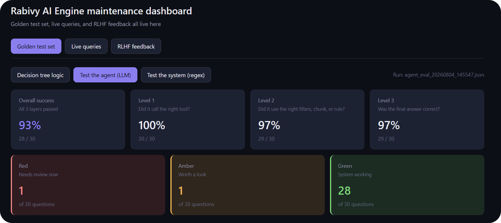

Golden Test Set tab

There are filters that can be applied to filter which items to show. Below is a screenshot of amber and red items. We can see that question 13 passed level 1 and level 2 meaning it routed correctly and retrieved the correct evidence, but the answer was still incorrect. This suggests that there was a synthesis issue, which is shown in the diagnosis box. Question 23 failed level 2 but passed level 3 which indicates that despite not having the correct evidence the answer was “correct anyway”. This is where you can go into any failures and evaluate the problem more closely.

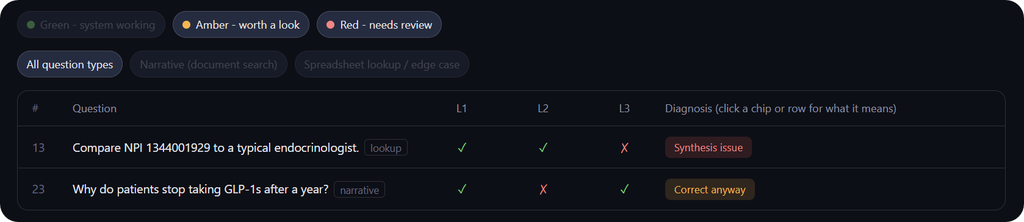

Golden Test Set Example

By clicking on an item it shows the question, the answer given, and the layer by layer breakdown so the issue can be investigated in depth. See below.

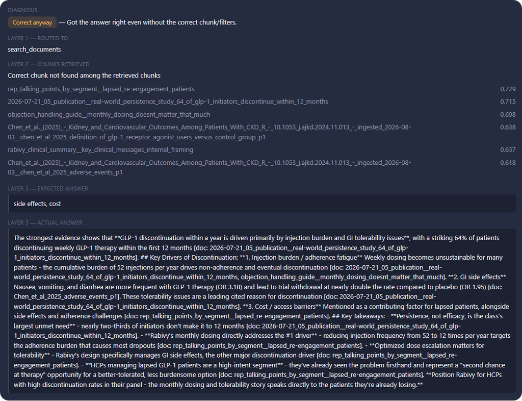

Golden Test Set Item Example

There is also a trendline that tracks the number of items within each priority group overtime. Each eval run is saved and is compiled into a trend across time. In a live system with new data being ingested, if the golden test set were dynamic this would be able to show how fails track across new data ingestions. Currently as we are not ingesting new data, this simply shows the Golden test set evals runs over time.

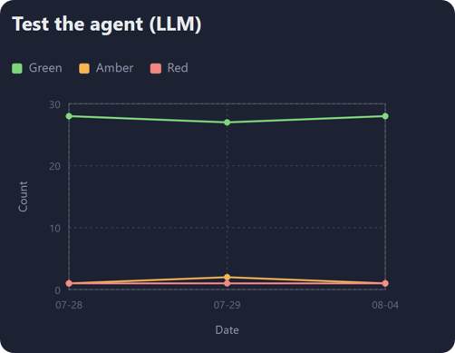

Golden Test Set Trendline Over Time

## Live Queries Tab

Below is a screenshot of the KPI boxes highlighting key metrics within the live query tab.

Box 1 - How many of the live questions passed all four gates

Box 2 - Tool grounding pass rate

Box 3 - Retrieval confidence pass rate

Box 4 - Source citations pass rate

Box 5 - Hallucination audit pass rate

Red box - Number of red level items -> review needed

Amber box - Number of amber level items -> potential/batch review

Green box - Number of green items -> working properly, no action.

Blue box - number of queries reviewed by users

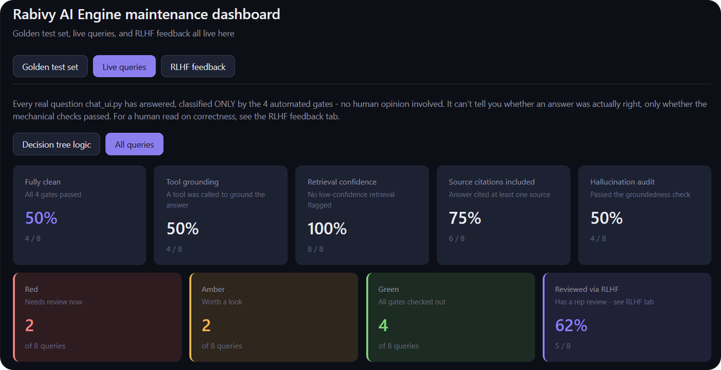

Live Queries tab

Below is a screenshot of the amber and red live queries. You can see exactly which gates failed, providing more information on what went wrong. Furthermore, by clicking on the item all the information stored from that specific query is presented, similarly to above in the golden test set tab.

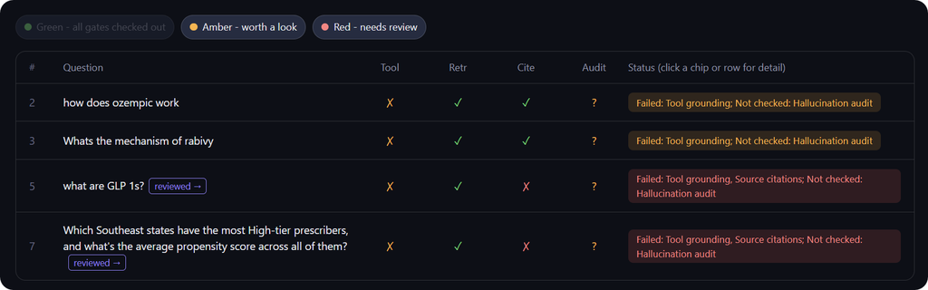

Live Queries examples

This tab also tracks the number of items within each priority group overtime so that the prevalence of each problem can be traced.

## RLHF Tab

Below is a screenshot of the KPI boxes highlighting key metrics within the RLHF tab.

Red box - Number of red level items -> review needed

Amber box - Number of amber level items -> potential/batch review

Green box - Number of green items -> working properly, no action.

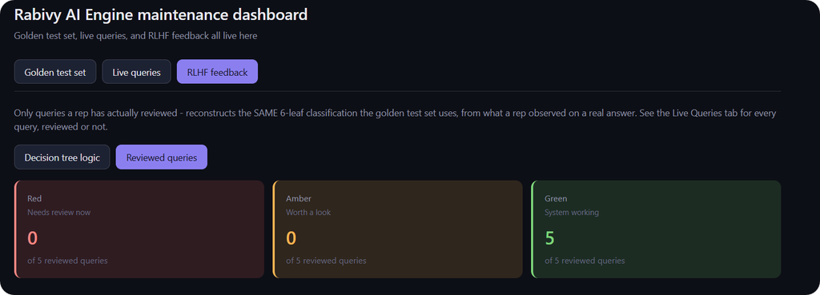

RLHF feedback tab

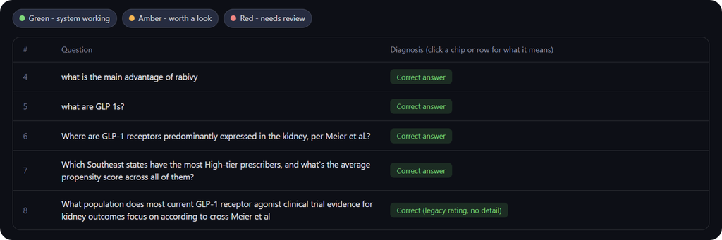

RLHF feedback examples

This tab also tracks the number of items within each priority group overtime so that the prevalence of each problem can be traced.

# Keeping it current

The dashboard is a static file (`dashboard.html`), rebuilt by running `python build_dashboard.py` - it isn’t wired into any automatic pipeline yet, so it only reflects data as of whenever it was last rebuilt and pushed. A few things worth knowing about what that actually involves:

- **The two logs are the real source of truth.** `output/QUERY_LOG/query_log.jsonl` (every question) and `output/RLHF_FEEDBACK/rlhf_log.jsonl` (only the reviewed ones) hold the raw data. `build_dashboard.py` reads both fresh every time it runs and rebuilds `dashboard.html` from scratch - nothing on the page updates on its own between rebuilds.
- **Labels are recomputed fresh, not trusted from storage.** Every time the dashboard is rebuilt, each reviewed question’s classification is recalculated from its raw stored fields (rating, evidence answer, whether the engine actually declined), rather than reusing whatever label was saved at the moment a rep submitted their review. That means a genuine logic fix - like the decline-flow fix or the retrieval-confidence gate fix described on the RLHF page - automatically corrects how *existing* entries get read the next time the dashboard is rebuilt.
- **That only goes so far.** If a rep’s underlying answer was itself captured wrong under an old, confusing version of the review flow - not just read wrong by old logic - rebuilding the dashboard can’t fix that on its own. That entry needs a rep to actually look at the question again and re-submit a review through the current flow.
- **Rebuilding and pushing is a manual step today.** After any change to the gate logic, the RLHF scoring, or a batch of new reviews worth surfacing, someone needs to run the build and commit the refreshed `dashboard.html` - there’s no CI job or scheduled rebuild doing this automatically yet.

*AX Consult Group. Rabivy is used here as a commercial analytics showcase and is not intended for clinical use.*

[View the project on GitHub](https://github.com/AX-Consult-Group/medical-Rabivy-AI-engine)

Project Overview Evaluation Suite Live Queries and RLHF Dashboard Write Up Maintenance Dashboard